# Wenxin Xi GR5015 Lab 1

Wenxin Xi

9/28/2021

```r
setwd("/Users/veron/OneDrive/Desktop/5015Lab/Lab1")
gss <-  read.csv("GSS.2006.csv.xls")
```

```r
names(gss)
```

```
##    [1] "vpsu"     "vstrat"   "adults"   "ballot"   "dateintv" "famgen"
##    [7] "form"     "formwt"   "gender1"  "hompop"   "id"       "intage"
##   [13] "intid"    "intyrs"   "mode"     "oversamp" "phase"    "race"
##   [19] "reg16"    "region"   "relate1"  "relhh1"   "relhhd1"  "respnum"
##   [25] "rvisitor" "sampcode" "sample"   "sex"      "size"     "spaneng"
##   [31] "srcbelt"  "version"  "visitors" "wtss"     "wtssall"  "wtssnr"
##   [37] "xnorcsiz" "year"     "hispanic" "rplace"   "degree"   "hefinfo"
##   [43] "wrkstat"  "racecen1" "marital"  "phone"    "comprend" "coop"
##   [49] "feeused"  "hhrace"   "lngthinv" "educ"     "childs"   "ethnum"
##   [55] "age"      "cohort"   "intrace1" "attend"   "inthisp"  "hhtype"
##   [61] "hhtype1"  "earnrs"   "whoelse6" "whoelse1" "whoelse2" "whoelse3"
##   [67] "whoelse4" "whoelse5" "partyid"  "relig"    "teens"    "preteen"
##   [73] "babies"   "reliten"  "dwelling" "vote04"   "mar1"     "zodiac"
##   [79] "old1"     "fund"     "polviews" "income"   "income06" "wrkslf"
##   [85] "isco681"  "isco88"   "occ80"    "prestg80" "wrkgovt"  "sei"
```

[output cut: 196 more lines]

```r
View(gss)
```

## 1. Use the table command, summary or describe commands, to tabulate one variable; and explain your results.

I chose to look at a variable that taking part with others in making decisions that affect respondents. This variable, wkdecide, is the frequency that respondents are affected by taking apart with others in making decisions. As Table 1 indicates, valid answers range from 1 to 4, where 1 represents often and 4 means never. Table 2, shows that most respondents are affected by taking part with others in making decisions. There are 39% respondents chose often and 36% chose sometimes. While only a quarter of respondents are rarely(15%) or never(10%) affected by taking part with others in making decisions.

## Table 1: wkdecide, from the Electronic Codebook

423. In your job, how often do you take part with others in making decisions that affect you? (WKDECIDE)

| wkdecide | Total | % |
| --- | --- | --- |
| 1) Often | 669 | 38.6 |
| 2) Sometimes | 615 | 35.5 |
| 3) Rarely | 260 | 15.0 |
| 4) Never | 164 | 9.5 |
| 8) Don’t know | 14 | 0.8 |
| 9) No answer | 12 | 0.7 |
| Missing | 2776 |  |
| TOTAL | 1734 | 100.0 |

```r
table(gss$wkdecide)
```

```
##
##   1   2   3   4
## 669 615 260 164
```

## Table 2: Distribution of wkdecide (percentages)

```r
prop.table(table(gss$wkdecide))
```

```
##
##          1          2          3          4
## 0.39168618 0.36007026 0.15222482 0.09601874
```

```r
round(prop.table(table(gss$wkdecide)),2)
```

```
##
##    1    2    3    4
## 0.39 0.36 0.15 0.10
```

## 2. Using either the plyr or doBy commands, compare the means and standard deviations for one variable, for at least two subgroups; and explain your results

I chose to look at a variable, physhlth, that reveals how many days respondents found their physical health was not good during the past 30 days including physical illness and injury, as Table 1 shows. I looked at differences in mean and median days of those days by marital status. I chose to compare respondents’ marital status because I think couples may take care of each other and better marital life improves people mental health and physical health. I wanted to see if it would be visible in the GSS 2006 data. As Table 3 shows, divorced people reported an average of 3.4 days that they found their physical health was not good while Married people reported an average of 2.1 days. Separated people reported the second most average days of poor physical health which is 2.7 and the third party is the widowed reported an average of 2.4 days. People who never married reported the second least average days of poor physical health days which is 2.2. I found that married people reported least average days of poor physical health, while divorced people reported the most. Married people seem to have the best physical health status than others especially divorced and separated.Median of average days of each marital status is 0: most people report no days of poor physical health. The very high standard deviations for each marital status indicate how skewed this variable is.

## Table 1: physhlth, from the Electronic Codebook

457. Now thinking about your physical health, which includes physical illness and injury, for how many days during the past 30 days was your physical health not good? (PHYSHLTH)

| physhlth | TOTAL | % |
| --- | --- | --- |
| 0) 0 | 1165 | 67.2 |
| 1) 1 | 85 | 4.9 |
| 2) 2 | 130 | 7.5 |
| 3) 3 | 66 | 3.8 |
| 4) 4 | 42 | 2.4 |
| 5) 5 | 46 | 2.7 |
| 6) 6 | 5 | 0.3 |
| 7) 7 | 30 | 1.7 |
| 8) 8 | 5 | 0.3 |
| 9) 9 | 1 | 0.1 |
| 10) 10 | 33 | 1.9 |
| 12) 12 | 4 | 0.2 |
| 14) 14 | 17 | 1.0 |
| 15) 15 | 14 | 0.8 |
| 18) 18 | 1 | 0.1 |
| 19) 19 | 1 | 0.1 |
| 20) 20 | 13 | 0.7 |
| 21) 21 | 6 | 0.3 |
| 22) 22 | 1 | 0.1 |
| 25) 25 | 3 | 0.2 |
| 27) 27 | 1 | 0.1 |
| 28) 28 | 3 | 0.2 |
| 30) 30 | 46 | 2.7 |
| 98) Don’t know | 4 | 0.2 |
| 99) No answer | 12 | 0.7 |
| Missing | 2776 |  |
| TOTAL | 1734 | 100.0 |

## Table 2: marital, from the Electronica Codebook

12)Are you currently – married, widowed, divorced, separated, or have you never been married? (MARITAL)

| marital | TOTAL | % |
| --- | --- | --- |
| 1) Married | 2170 | 48.1 |
| 2) Widowed | 366 | 8.1 |
| 3) Divorced | 732 | 16.2 |
| 4) Separated | 156 | 3.5 |
| 5) Never married | 1080 | 23.9 |
| 9) No answer | 6 | 0.1 |
| TOTAL | 4510 | 100.0 |

## Table 3: Key Descriptive Statistics of physhlth, by marital status

```r
library(doBy)
summaryBy(physhlth~marital, data=gss, FUN=c(mean,median, sd), na.rm=T)
```

```
##   marital physhlth.mean physhlth.median physhlth.sd
## 1       1      2.054697               0    5.594585
## 2       2      2.436364               0    6.887357
## 3       3      3.430421               0    7.427956
## 4       4      2.694915               0    6.314336
## 5       5      2.176600               0    5.270109
## 6      NA      0.000000               0          NA
```

```r
library(ggplot2)
```

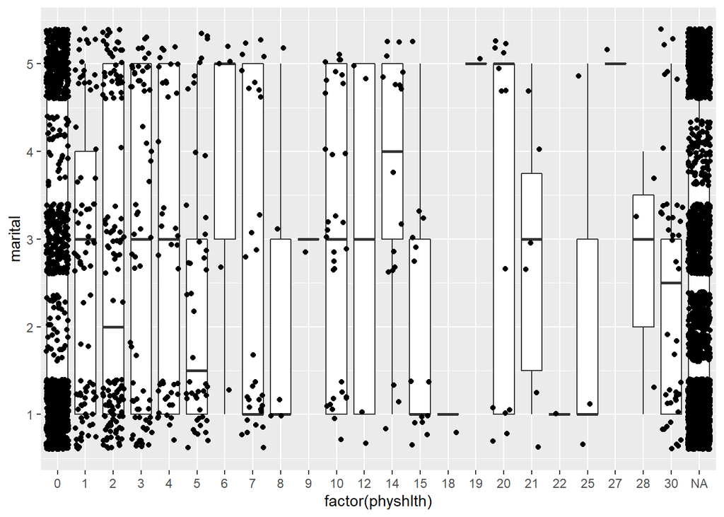

```r
p = ggplot(gss, aes(factor(physhlth), marital))
p + geom_boxplot() + geom_jitter()
```

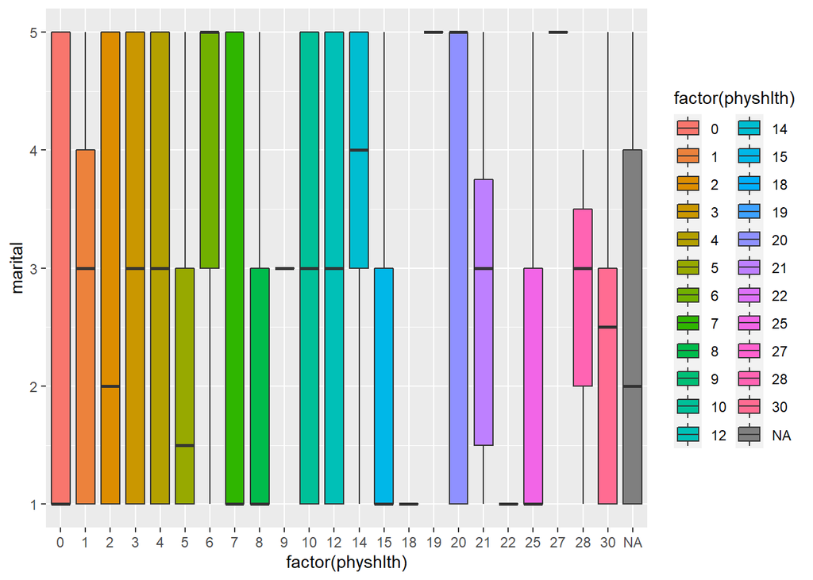

```r
p + geom_boxplot(aes(fill = factor(physhlth))) ## see how they include the NAs, which are the missings
```

## 3. Using the gmodels or another command, crosstabulate two categorical or ordinal variables (getting proportions); and explain your results

I chose to look at a variable, wrktime, that investigates respondents’ thought they had enough time to get the job done or not; as Table 1 indicates, the answers are ranging from 1)very true to 4)not at all true. I wanted to cross-tabulate that variable with whether respondents are self-employed or working for anyone else(showed in Table 2), named “wrkslf”. I hypothesized that self-employed people would choose very true for having enough time to get the job done since self-employed people can assign the work they need to finish by themselves. While in the most time, people who work for anyone else have work assigned by supervisors or employers that they may not have enough time to get the job done.There are 1699 people who had valid responses to both of two questions. The results in Table 3 partly support my hypotheses. Nearly 55% self-employed respondents choose very true that they have enough time to get the job done. While only 38% respondents who work for anyone else choose very true. Around 44% people who work for anyone else choose somewhat true and it shows they have enough time to get the job done possibly. The percentages of not too true and not at all true for people who work for anyone else are higher than self-employed people as well. These results seem to line up with as I hypothesized.

## Table 1: wrktime, from the Electronica Codebook

438. I have enough time to get the job done. (WRKTIME)

| wrktime | TOTAL | % |
| --- | --- | --- |
| 1) Very true | 687 | 39.6 |
| 2) Somewhat true | 723 | 41.7 |
| 3) Not too true | 205 | 11.8 |
| 4) Not at all true | 86 | 5.0 |
| 8) Don’t know | 15 | 0.9 |
| 9) No answer | 18 | 1.0 |
| Missing | 2776 |  |
| TOTAL | 1734 | 100.0 |

## Table 2: wrkslf, from the Electronica Codebook

7)(Are/Were) you self employed or (do/did) you work for someone else? (WRKSLF)

| wrkslf | TOTAL | % |
| --- | --- | --- |
| 1) Self-employed | 508 | 11.8 |
| 2) Someone else | 3799 | 87.9 |
| 8) Don’t know | 3 | 0.1 |
| 9) No answer | 13 | 0.3 |
| Missing | 187 |  |
| TOTAL | 4323 | 100.0 |

## Table 3: Cross-Tabulation of the Number of respondents thought they had enough time to get the job done(wrktime), with the Respondents’ Self-employed or working for someone else(wrkslf)

```r
library(gmodels)
CrossTable(gss$wrktime, gss$wrkslf, prop.r=F, prop.c=T, prop.t=F, prop.chisq=F, format="SPSS")
```

```
##
##    Cell Contents
## |-------------------------|
## |                   Count |
## |          Column Percent |
## |-------------------------|
##
## Total Observations in Table:  1699
##
##              | gss$wrkslf
##  gss$wrktime |        1  |        2  | Row Total |
## -------------|-----------|-----------|-----------|
##            1 |      117  |      569  |      686  |
##              |   54.673% |   38.316% |           |
## -------------|-----------|-----------|-----------|
##            2 |       77  |      646  |      723  |
##              |   35.981% |   43.502% |           |
## -------------|-----------|-----------|-----------|
##            3 |       13  |      192  |      205  |
##              |    6.075% |   12.929% |           |
## -------------|-----------|-----------|-----------|
##            4 |        7  |       78  |       85  |
##              |    3.271% |    5.253% |           |
## -------------|-----------|-----------|-----------|
## Column Total |      214  |     1485  |     1699  |
##              |   12.596% |   87.404% |           |
## -------------|-----------|-----------|-----------|
##
##
```